# Query Analytics Workloads — Validation & Diagnostics

Prasanna Renapurkar · Validation & Report Integrator

Team — UCI #493 Query Analytics Workloads

2026-05-04

# Setup

Run this chunk first — installs missing packages and creates output directories.

```r
options(repos = c(CRAN = "https://cloud.r-project.org"))

pkgs <- c("readr", "dplyr", "ggplot2", "xgboost", "cluster",
          "Metrics", "tidyr", "viridis", "gridExtra", "scales")
for (p in pkgs) {
  if (!requireNamespace(p, quietly = TRUE)) install.packages(p)
}

library(readr);  library(dplyr);   library(ggplot2)
library(xgboost); library(cluster); library(Metrics)
library(tidyr);  library(viridis); library(gridExtra); library(scales)

set.seed(42)
dir.create("../results",        showWarnings = FALSE)
dir.create("../report/figures", showWarnings = FALSE, recursive = TRUE)
```

# Chunk 1 — Load Data + Feature Engineering

Mirrors `03_modeling.Rmd` Chunks 1–2 exactly so the validation re-derives the same feature matrices the trained models saw.

```r
range_log  <- read_csv("../data/processed/clean_range_queries_log.csv")
radius_log <- read_csv("../data/processed/clean_radius_count_log.csv")

# Range FE
x_min_r <- min(range_log$X); x_max_r <- max(range_log$X)
y_min_r <- min(range_log$Y); y_max_r <- max(range_log$Y)

range_fe <- range_log %>%
  mutate(
    aspect_ratio       = X_range / (Y_range + 1e-9),
    log_area           = log1p(area),
    interact_area_dist = log_area * dist_centroid,
    boundary_flag      = as.integer(
      (X - X_range / 2 < x_min_r) | (X + X_range / 2 > x_max_r) |
      (Y - Y_range / 2 < y_min_r) | (Y + Y_range / 2 > y_max_r)
    )
  )

# Radius FE — boundary_flag constant for radius queries, omitted
radius_fe <- radius_log %>%
  mutate(
    log_area           = log1p(area),
    interact_area_dist = area * dist_centroid
  )

cat("Range :", nrow(range_fe),  "rows\n")
```

```
## Range : 200000 rows
```

```r
cat("Radius:", nrow(radius_fe), "rows\n")
```

```
## Radius: 10000 rows
```

# Chunk 2 — Reproduce Train / Test Split (seed = 42)

Saved model files in `models/` are Git-LFS pointer stubs in this checkout, so we re-create the 80/20 split with the same seed used in `03_modeling.Rmd` and refit XGBoost from `xgb_best_params.csv`. The split is identical to the one in `results/split_range.csv` / `results/split_radius.csv`.

```r
set.seed(42)
n_range       <- nrow(range_fe)
train_idx_r   <- sample(n_range, size = floor(0.8 * n_range))
test_idx_r    <- setdiff(seq_len(n_range), train_idx_r)
range_train   <- range_fe[train_idx_r, ]
range_test    <- range_fe[test_idx_r,  ]

n_radius      <- nrow(radius_fe)
train_idx_rad <- sample(n_radius, size = floor(0.8 * n_radius))
test_idx_rad  <- setdiff(seq_len(n_radius), train_idx_rad)
radius_train  <- radius_fe[train_idx_rad, ]
radius_test   <- radius_fe[test_idx_rad,  ]

cat(sprintf("Range  : train=%d  test=%d\n", nrow(range_train),  nrow(range_test)))
```

```
## Range  : train=160000  test=40000
```

```r
cat(sprintf("Radius : train=%d  test=%d\n", nrow(radius_train), nrow(radius_test)))
```

```
## Radius : train=8000  test=2000
```

# Chunk 3 — Refit XGBoost (Range + Radius)

```r
best_params <- read_csv("../results/xgb_best_params.csv", show_col_types = FALSE)
br_range  <- best_params %>% filter(dataset == "range")  %>% slice(1)
br_radius <- best_params %>% filter(dataset == "radius") %>% slice(1)

xgb_feats_range <- c("log_area", "X_range", "Y_range", "dist_centroid",
                     "aspect_ratio", "interact_area_dist", "boundary_flag",
                     "X_norm", "Y_norm")
xgb_feats_rad   <- c("R", "log_area", "dist_centroid",
                     "interact_area_dist", "X_norm", "Y_norm")

dtrain_r   <- xgb.DMatrix(as.matrix(range_train [, xgb_feats_range]), label = range_train$log_Count)
dtest_r    <- xgb.DMatrix(as.matrix(range_test  [, xgb_feats_range]), label = range_test $log_Count)
dtrain_rad <- xgb.DMatrix(as.matrix(radius_train[, xgb_feats_rad]),   label = radius_train$log_Count)
dtest_rad  <- xgb.DMatrix(as.matrix(radius_test [, xgb_feats_rad]),   label = radius_test $log_Count)

set.seed(42)
xgb_range <- xgb.train(
  params  = list(objective = "reg:squarederror",
                 eta = br_range$eta, max_depth = br_range$max_depth,
                 subsample = br_range$subsample, colsample_bytree = 0.8, seed = 42),
  data    = dtrain_r,
  nrounds = br_range$best_round,
  verbose = 0
)

set.seed(42)
xgb_radius <- xgb.train(
  params  = list(objective = "reg:squarederror",
                 eta = br_radius$eta, max_depth = br_radius$max_depth,
                 subsample = br_radius$subsample, colsample_bytree = 0.8, seed = 42),
  data    = dtrain_rad,
  nrounds = br_radius$best_round,
  verbose = 0
)

# Predictions and residuals on test sets (log scale + original scale)
range_test  <- range_test  %>% mutate(
  pred_log  = predict(xgb_range,  dtest_r),
  actual    = expm1(log_Count),
  pred      = pmax(0, expm1(pred_log)),
  resid_log = log_Count - pred_log,
  resid     = actual - pred
)
radius_test <- radius_test %>% mutate(
  pred_log  = predict(xgb_radius, dtest_rad),
  actual    = expm1(log_Count),
  pred      = pmax(0, expm1(pred_log)),
  resid_log = log_Count - pred_log,
  resid     = actual - pred
)

cat(sprintf("Range  XGB test RMSE = %10.2f  R^2 = %.4f\n",
            rmse(range_test$actual,  range_test$pred),
            1 - sum((range_test$actual  - range_test$pred )^2) /
                sum((range_test$actual  - mean(range_test$actual ))^2)))
```

```
## Range  XGB test RMSE =    6575.36  R^2 = 0.9982
```

```r
cat(sprintf("Radius XGB test RMSE = %10.2f  R^2 = %.4f\n",
            rmse(radius_test$actual, radius_test$pred),
            1 - sum((radius_test$actual - radius_test$pred)^2) /
                sum((radius_test$actual - mean(radius_test$actual))^2)))
```

```
## Radius XGB test RMSE =       8.52  R^2 = 0.9958
```

# Chunk 4 — Final Benchmark (`results/final_benchmark.csv`)

Reshapes `results/cv_comparison.csv` into a single train+test side-by-side table (deliverable named in the sprint plan).

```r
cv <- read_csv("../results/cv_comparison.csv", show_col_types = FALSE)

final_bench <- cv %>%
  pivot_wider(names_from = split,
              values_from = c(RMSE, MAE, R2, MAPE),
              names_sep = "_") %>%
  arrange(dataset, RMSE_test)

write_csv(final_bench, "../results/final_benchmark.csv")
cat("[OK] results/final_benchmark.csv written\n")
```

```
## [OK] results/final_benchmark.csv written
```

```r
knitr::kable(final_bench, digits = 4,
             caption = "Final benchmark — train and test metrics, all models")
```

Final benchmark — train and test metrics, all models

| dataset | model | RMSE_train | RMSE_test | MAE_train | MAE_test | R2_train | R2_test | MAPE_train | MAPE_test |
| --- | --- | --- | --- | --- | --- | --- | --- | --- | --- |
| radius | xgboost | 6.3079 | 8.5243 | 4.0978 | 5.1266 | 0.9976 | 0.9958 | 1.7309 | 2.3075 |
| radius | randomForest | 5.2735 | 9.0143 | 1.9468 | 4.0177 | 0.9983 | 0.9953 | 0.8352 | 1.9595 |
| radius | knn_k5 | 8.6423 | 10.5600 | 5.0161 | 6.0461 | 0.9956 | 0.9935 | 2.1240 | 2.7407 |
| radius | linear | 109.8623 | 108.8047 | 85.0267 | 83.2060 | 0.2831 | 0.3151 | 35.4896 | 35.5001 |
| range | xgboost | 5774.7793 | 6575.3618 | 3886.9909 | 4410.8947 | 0.9986 | 0.9982 | 4.2097 | 10.6079 |
| range | randomForest | 3438.5284 | 7801.0084 | 2033.9261 | 4667.9305 | 0.9995 | 0.9974 | 4.1806 | 15.8291 |
| range | knn_k10 | 19862.1062 | 21741.8807 | 12885.7144 | 14091.1981 | 0.9835 | 0.9801 | 20.1871 | 22.2431 |
| range | linear | 59797.2182 | 59654.7330 | 40547.9436 | 40427.8724 | 0.8503 | 0.8505 | 103.5922 | 82.0161 |

# Chunk 5 — M4: Residual Diagnostics for XGBoost

Four-panel diagnostic figure: 1. Range — fitted vs residual (log scale) with LOESS overlay → heteroscedasticity check 2. Radius — fitted vs residual (log scale) 3. Range — predicted vs actual (original Count scale) 4. Radius — predicted vs actual

Test sets are sub-sampled for plotting; metrics use the full test set.

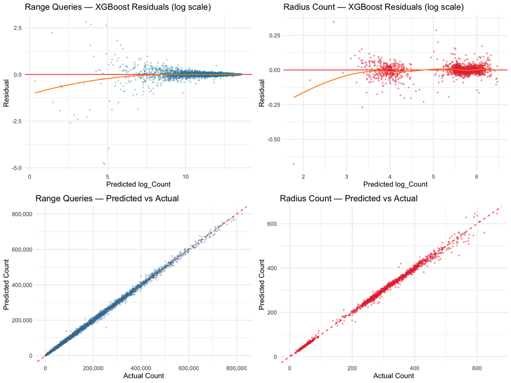

```r
set.seed(42)
samp_r  <- sample_n(range_test,  size = min(5000, nrow(range_test)))
samp_rd <- sample_n(radius_test, size = min(2000, nrow(radius_test)))

p1 <- ggplot(samp_r, aes(pred_log, resid_log)) +
  geom_point(alpha = 0.3, size = 0.6, color = "#2E86AB") +
  geom_hline(yintercept = 0, color = "red", linewidth = 0.5) +
  geom_smooth(method = "loess", color = "darkorange", se = FALSE, linewidth = 0.7) +
  labs(title = "Range Queries — XGBoost Residuals (log scale)",
       x = "Predicted log_Count", y = "Residual") +
  theme_minimal(base_size = 12)

p2 <- ggplot(samp_rd, aes(pred_log, resid_log)) +
  geom_point(alpha = 0.4, size = 0.7, color = "#E63946") +
  geom_hline(yintercept = 0, color = "red", linewidth = 0.5) +
  geom_smooth(method = "loess", color = "darkorange", se = FALSE, linewidth = 0.7) +
  labs(title = "Radius Count — XGBoost Residuals (log scale)",
       x = "Predicted log_Count", y = "Residual") +
  theme_minimal(base_size = 12)

p3 <- ggplot(samp_r, aes(actual, pred)) +
  geom_point(alpha = 0.3, size = 0.6, color = "#2E86AB") +
  geom_abline(slope = 1, intercept = 0, color = "red", linetype = "dashed") +
  scale_x_continuous(labels = comma) +
  scale_y_continuous(labels = comma) +
  labs(title = "Range Queries — Predicted vs Actual",
       x = "Actual Count", y = "Predicted Count") +
  theme_minimal(base_size = 12)

p4 <- ggplot(samp_rd, aes(actual, pred)) +
  geom_point(alpha = 0.4, size = 0.7, color = "#E63946") +
  geom_abline(slope = 1, intercept = 0, color = "red", linetype = "dashed") +
  labs(title = "Radius Count — Predicted vs Actual",
       x = "Actual Count", y = "Predicted Count") +
  theme_minimal(base_size = 12)

fig08 <- arrangeGrob(p1, p2, p3, p4, ncol = 2)
ggsave("../report/figures/fig08_residuals_xgb.png", fig08,
       width = 12, height = 9, dpi = 300)
grid::grid.draw(fig08)
```

```r
cat("[OK] report/figures/fig08_residuals_xgb.png saved\n")
```

```
## [OK] report/figures/fig08_residuals_xgb.png saved
```

# Chunk 6 — D3 (part 1): Bias by `log_area` Decile (Range)

XGBoost test-set RMSE is computed within each `log_area` decile to surface where the model under-performs.

```r
range_test_b <- range_test %>%
  mutate(area_decile = ntile(log_area, 10))

bias_decile <- range_test_b %>%
  group_by(area_decile) %>%
  summarise(
    n           = n(),
    min_area    = min(area),
    max_area    = max(area),
    mean_actual = mean(actual),
    rmse        = rmse(actual, pred),
    mae         = mae(actual, pred),
    mape        = mean(abs((actual - pred) / (actual + 1))) * 100,
    .groups     = "drop"
  ) %>%
  arrange(area_decile)

write_csv(bias_decile, "../results/bias_by_decile.csv")
knitr::kable(bias_decile, digits = 2,
             caption = "XGBoost test-set error by log_area decile (Range)")
```

XGBoost test-set error by log_area decile (Range)

| area_decile | n | min_area | max_area | mean_actual | rmse | mae | mape |
| --- | --- | --- | --- | --- | --- | --- | --- |
| 1 | 4000 | 274.69 | 10340576 | 6106.97 | 1410.93 | 932.44 | 65.51 |
| 2 | 4000 | 10343846.71 | 25286708 | 22385.10 | 2546.55 | 1860.61 | 11.22 |
| 3 | 4000 | 25291726.91 | 43686619 | 44154.86 | 3681.10 | 2640.17 | 6.44 |
| 4 | 4000 | 43689690.78 | 66836967 | 69082.01 | 4435.86 | 3295.18 | 5.16 |
| 5 | 4000 | 66840780.49 | 94431338 | 100445.75 | 5534.80 | 3970.46 | 4.24 |
| 6 | 4000 | 94434254.84 | 127174153 | 138055.59 | 6239.61 | 4565.32 | 3.52 |
| 7 | 4000 | 127175201.35 | 167500498 | 183025.00 | 7761.75 | 5668.59 | 3.25 |
| 8 | 4000 | 167518645.23 | 221840661 | 241373.65 | 8064.54 | 6162.25 | 2.70 |
| 9 | 4000 | 221870716.98 | 297417546 | 322370.51 | 8825.58 | 6717.89 | 2.19 |
| 10 | 4000 | 297438474.11 | 506546405 | 464461.58 | 10858.71 | 8296.03 | 1.86 |

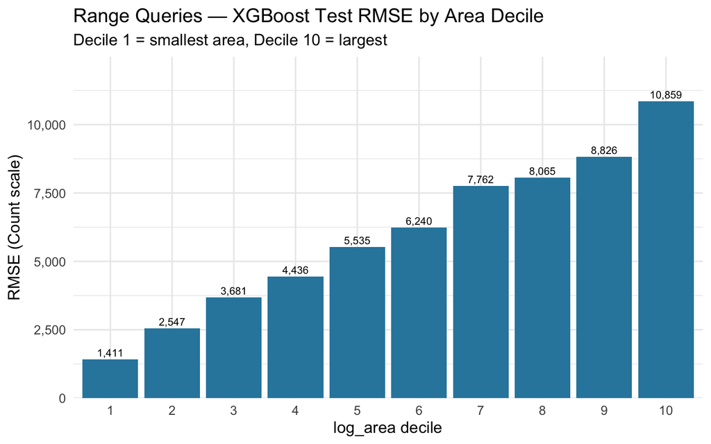

```r
p_bias <- ggplot(bias_decile, aes(factor(area_decile), rmse)) +
  geom_col(fill = "#2E86AB") +
  geom_text(aes(label = comma(round(rmse))), vjust = -0.4, size = 3) +
  scale_y_continuous(labels = comma, expand = expansion(mult = c(0, 0.15))) +
  labs(title    = "Range Queries — XGBoost Test RMSE by Area Decile",
       subtitle = "Decile 1 = smallest area, Decile 10 = largest",
       x = "log_area decile", y = "RMSE (Count scale)") +
  theme_minimal(base_size = 13)

ggsave("../report/figures/fig09_bias_by_quantile.png", p_bias,
       width = 8, height = 5, dpi = 300)
print(p_bias)
```

```r
cat("[OK] report/figures/fig09_bias_by_quantile.png saved\n")
```

```
## [OK] report/figures/fig09_bias_by_quantile.png saved
```

# Chunk 7 — D1: K-Means K ∈ {3, 4, 5} with Silhouette Selection

K-Means is fit on (X_norm, Y_norm, log_area_norm) for the Range Queries sub-dataset (largest sample, 200k rows). Silhouette score is computed on a 5,000-row sample because `silhouette()` requires an n × n distance matrix (O(n²) memory).

```r
norm_min_max <- function(x) (x - min(x)) / (max(x) - min(x) + 1e-12)

km_data <- range_fe %>%
  transmute(X_norm,
            Y_norm,
            log_area_norm = norm_min_max(log_area)) %>%
  as.matrix()

set.seed(42)
sil_idx  <- sample(nrow(km_data), 5000)
sil_data <- km_data[sil_idx, ]
sil_dist <- dist(sil_data)

km_results <- list()
sil_scores <- numeric(3)
ks         <- c(3, 4, 5)

for (i in seq_along(ks)) {
  k <- ks[i]
  set.seed(42)
  km_full <- kmeans(km_data, centers = k, nstart = 10, iter.max = 50)
  km_results[[as.character(k)]] <- km_full

  set.seed(42)
  km_sub <- kmeans(sil_data, centers = k, nstart = 10, iter.max = 50)
  sil    <- silhouette(km_sub$cluster, sil_dist)
  sil_scores[i] <- mean(sil[, 3])
  cat(sprintf("K = %d  silhouette = %.4f  WSS = %.2f\n",
              k, sil_scores[i], km_full$tot.withinss))
}
```

```
## K = 3  silhouette = 0.6297  WSS = 3970.02
```

```
## K = 4  silhouette = 0.5274  WSS = 3163.76
## K = 5  silhouette = 0.4465  WSS = 2676.96
```

```r
best_k  <- ks[which.max(sil_scores)]
km_best <- km_results[[as.character(best_k)]]
cat("\nBest K (silhouette):", best_k, "\n")
```

```
##
## Best K (silhouette): 3
```

```r
range_fe$cluster <- factor(km_best$cluster)
```

# Chunk 8 — D2: 2D Cluster Map

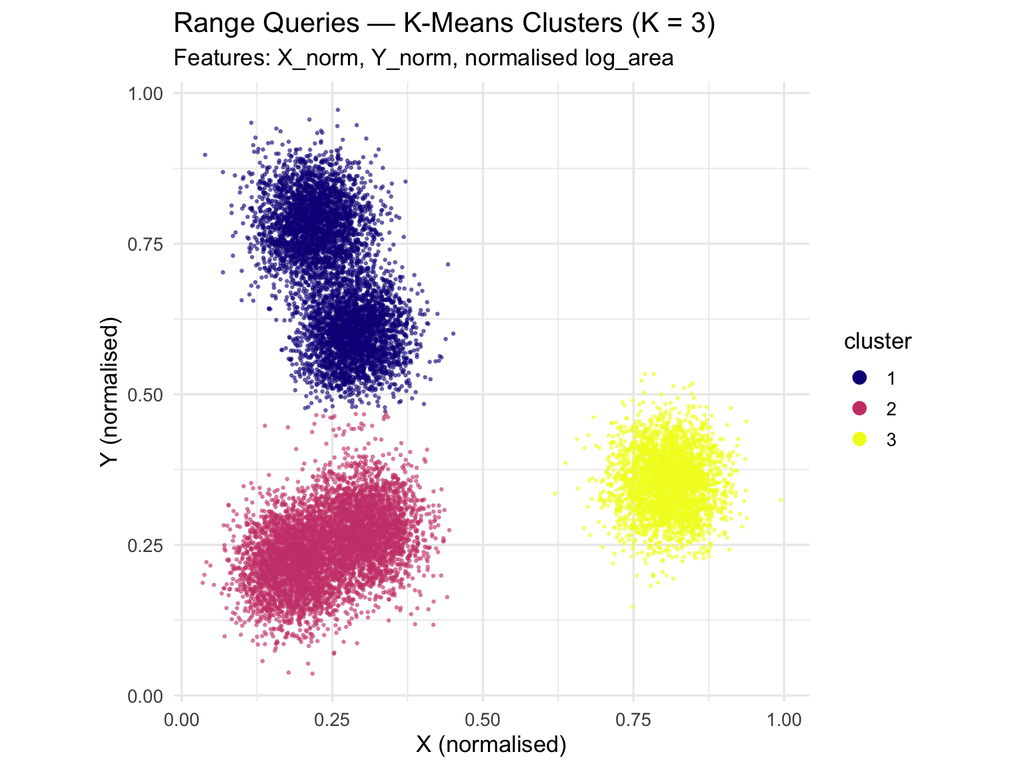

```r
set.seed(42)
samp_clu <- range_fe %>% sample_n(min(15000, n()))

p_clu <- ggplot(samp_clu, aes(X_norm, Y_norm, color = cluster)) +
  geom_point(alpha = 0.5, size = 0.4) +
  scale_color_viridis_d(option = "plasma") +
  coord_equal() +
  labs(title    = paste0("Range Queries — K-Means Clusters (K = ", best_k, ")"),
       subtitle = "Features: X_norm, Y_norm, normalised log_area",
       x = "X (normalised)", y = "Y (normalised)") +
  theme_minimal(base_size = 13) +
  guides(color = guide_legend(override.aes = list(size = 3, alpha = 1)))

ggsave("../report/figures/fig10_clusters.png", p_clu,
       width = 8, height = 6, dpi = 300)
print(p_clu)
```

```r
cat("[OK] report/figures/fig10_clusters.png saved\n")
```

```
## [OK] report/figures/fig10_clusters.png saved
```

# Chunk 9 — D3 (part 2): Bias by Spatial Cluster

Joins each test row to its K-Means cluster (via `test_idx_r`) and reports per-cluster XGBoost RMSE — surfaces which Chicago zones the model handles worst.

```r
range_test_c <- range_test %>%
  mutate(cluster = factor(km_best$cluster[test_idx_r]))

bias_cluster <- range_test_c %>%
  group_by(cluster) %>%
  summarise(
    n              = n(),
    mean_actual    = mean(actual),
    rmse           = rmse(actual, pred),
    mae            = mae(actual, pred),
    mape           = mean(abs((actual - pred) / (actual + 1))) * 100,
    pct_boundary   = mean(boundary_flag) * 100,
    .groups        = "drop"
  ) %>%
  arrange(desc(rmse))

write_csv(bias_cluster, "../results/bias_by_cluster.csv")
knitr::kable(bias_cluster, digits = 2,
             caption = "XGBoost test-set error by K-Means cluster (Range)")
```

XGBoost test-set error by K-Means cluster (Range)

| cluster | n | mean_actual | rmse | mae | mape | pct_boundary |
| --- | --- | --- | --- | --- | --- | --- |
| 3 | 7927 | 150643.4 | 7653.45 | 5012.14 | 11.37 | 0.86 |
| 1 | 15990 | 207480.0 | 7079.26 | 4978.56 | 9.82 | 0.49 |
| 2 | 16083 | 115282.5 | 5369.72 | 3550.17 | 11.02 | 0.80 |

# Summary

```r
cat("── Validation deliverables written ──\n")
```

```
## ── Validation deliverables written ──
```

```r
cat("  results/final_benchmark.csv\n")
```

```
##   results/final_benchmark.csv
```

```r
cat("  results/bias_by_decile.csv\n")
```

```
##   results/bias_by_decile.csv
```

```r
cat("  results/bias_by_cluster.csv\n")
```

```
##   results/bias_by_cluster.csv
```

```r
cat("  report/figures/fig08_residuals_xgb.png\n")
```

```
##   report/figures/fig08_residuals_xgb.png
```

```r
cat("  report/figures/fig09_bias_by_quantile.png\n")
```

```
##   report/figures/fig09_bias_by_quantile.png
```

```r
cat("  report/figures/fig10_clusters.png\n\n")
```

```
##   report/figures/fig10_clusters.png
```

```r
cat(sprintf("Best K (silhouette): %d (silhouette = %.4f)\n",
            best_k, max(sil_scores)))
```

```
## Best K (silhouette): 3 (silhouette = 0.6297)
```

```r
cat(sprintf("Range  XGB test RMSE: %.2f\n", rmse(range_test$actual,  range_test$pred)))
```

```
## Range  XGB test RMSE: 6575.36
```

```r
cat(sprintf("Radius XGB test RMSE: %.2f\n", rmse(radius_test$actual, radius_test$pred)))
```

```
## Radius XGB test RMSE: 8.52
```